# Australian cancer profile

## Summary

For Breast cancer (C50), AIHW reported **19,031** new cases among persons in 2021, with an age-standardised incidence rate of **64.1 per 100,000**. The published ASR increased from the previous observed year. Projected years are shown separately and are not used for this sentence.

The incidence and mortality workbooks use the same published ICD-10 definition for this cancer.

## Incidence and mortality trends

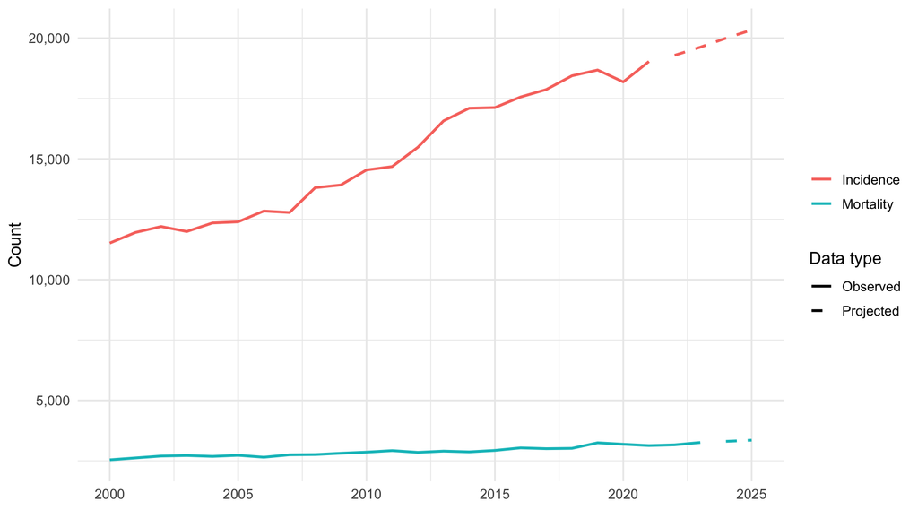

Published counts for persons; dashed lines denote AIHW projections.

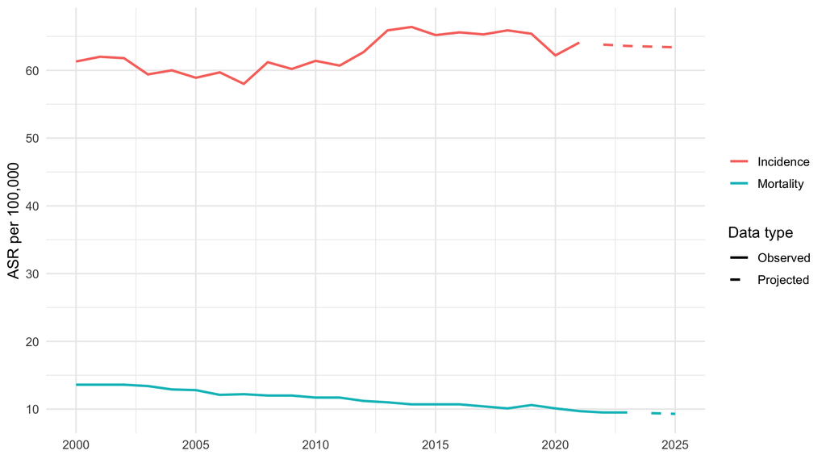

Published age-standardised rates for persons (2001 Australian Standard Population).

## Recent year-on-year incidence change

| Year | ASR | Previous ASR | Change | % change | Projection |
| --- | --- | --- | --- | --- | --- |
| 2025 | 63.4 | 63.5 | -0.1 | -0.16 | TRUE |
| 2024 | 63.5 | 63.6 | -0.1 | -0.16 | TRUE |
| 2023 | 63.6 | 63.8 | -0.2 | -0.31 | TRUE |
| 2022 | 63.8 | 64.1 | -0.3 | -0.47 | TRUE |
| 2021 | 64.1 | 62.2 | 1.9 | 3.05 | FALSE |
| 2020 | 62.2 | 65.4 | -3.2 | -4.89 | FALSE |
| 2019 | 65.4 | 65.9 | -0.5 | -0.76 | FALSE |
| 2018 | 65.9 | 65.3 | 0.6 | 0.92 | FALSE |
| 2017 | 65.3 | 65.6 | -0.3 | -0.46 | FALSE |
| 2016 | 65.6 | 65.2 | 0.4 | 0.61 | FALSE |

## Age profile

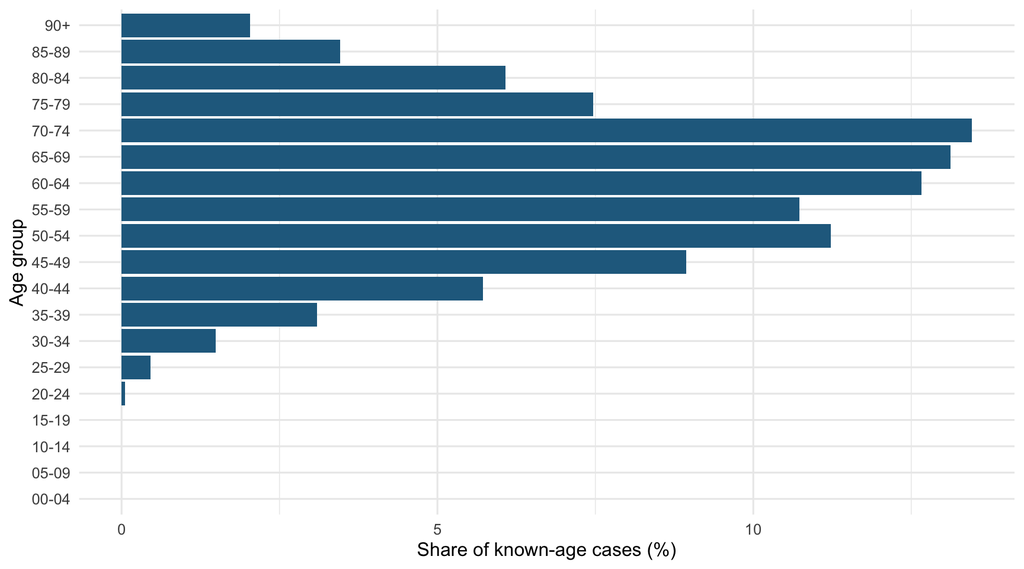

Share of observed cases across known 5-year age bands in the latest observed year.

## Data quality status

| Check | Table | Problem rows | Status |
| --- | --- | --- | --- |
| qa_duplicate_keys | incidence | 0 | PASS |
| qa_duplicate_keys | mortality | 0 | PASS |
| qa_missing_years | incidence | 0 | PASS |
| qa_missing_years | mortality | 0 | PASS |
| qa_negative_or_implausible | incidence | 0 | PASS |
| qa_negative_or_implausible | mortality | 0 | PASS |
| qa_null_values | incidence | 0 | PASS |
| qa_null_values | mortality | 0 | PASS |
| qa_orphan_cancer_types | incidence | 0 | PASS |
| qa_orphan_cancer_types | mortality | 0 | PASS |

## Source and caveats

Source: Australian Institute of Health and Welfare, *Cancer Data in Australia 2025*, Book 1a (Australian Cancer Database incidence) and Book 2a (National Mortality Database mortality), downloaded from the [AIHW data page](https://www.aihw.gov.au/reports/cancer/cancer-data-in-australia/data).

These are national aggregate data, not NSW or record-level data. Rates are used exactly as published; this project does not calculate age standardisation. AIHW incidence is observed through 2021 and projected from 2022 to 2025; NMD mortality is observed through 2023 and projected from 2024 to 2025. Age-profile percentages use known-age bands, while the published all-ages total can include unknown ages.